# 根据语音识别性别

```python
import numpy as np
import pandas as pd
import matplotlib.pyplot as plt
import seaborn as sns
import warnings
warnings.filterwarnings('ignore')
# warnings.filterwarnings(action ='ignore',category = DeprecationWarning)
# warnings.filterwarnings(action ='ignore',category=DeprecationWarning, module='xgboost')
%matplotlib inline
```

```python
#加载数据集
df = pd.read_csv('voice.csv')
df.head(10)
```

|  | meanfreq | sd | median | Q25 | Q75 | IQR | skew | kurt | sp.ent | sfm | ... | centroid | meanfun | minfun | maxfun | meandom | mindom | maxdom | dfrange | modindx | label |
| --- | --- | --- | --- | --- | --- | --- | --- | --- | --- | --- | --- | --- | --- | --- | --- | --- | --- | --- | --- | --- | --- |
| 0 | 0.059781 | 0.064241 | 0.032027 | 0.015071 | 0.090193 | 0.075122 | 12.863462 | 274.402906 | 0.893369 | 0.491918 | ... | 0.059781 | 0.084279 | 0.015702 | 0.275862 | 0.007812 | 0.007812 | 0.007812 | 0.000000 | 0.000000 | male |
| 1 | 0.066009 | 0.067310 | 0.040229 | 0.019414 | 0.092666 | 0.073252 | 22.423285 | 634.613855 | 0.892193 | 0.513724 | ... | 0.066009 | 0.107937 | 0.015826 | 0.250000 | 0.009014 | 0.007812 | 0.054688 | 0.046875 | 0.052632 | male |
| 2 | 0.077316 | 0.083829 | 0.036718 | 0.008701 | 0.131908 | 0.123207 | 30.757155 | 1024.927705 | 0.846389 | 0.478905 | ... | 0.077316 | 0.098706 | 0.015656 | 0.271186 | 0.007990 | 0.007812 | 0.015625 | 0.007812 | 0.046512 | male |
| 3 | 0.151228 | 0.072111 | 0.158011 | 0.096582 | 0.207955 | 0.111374 | 1.232831 | 4.177296 | 0.963322 | 0.727232 | ... | 0.151228 | 0.088965 | 0.017798 | 0.250000 | 0.201497 | 0.007812 | 0.562500 | 0.554688 | 0.247119 | male |
| 4 | 0.135120 | 0.079146 | 0.124656 | 0.078720 | 0.206045 | 0.127325 | 1.101174 | 4.333713 | 0.971955 | 0.783568 | ... | 0.135120 | 0.106398 | 0.016931 | 0.266667 | 0.712812 | 0.007812 | 5.484375 | 5.476562 | 0.208274 | male |
| 5 | 0.132786 | 0.079557 | 0.119090 | 0.067958 | 0.209592 | 0.141634 | 1.932562 | 8.308895 | 0.963181 | 0.738307 | ... | 0.132786 | 0.110132 | 0.017112 | 0.253968 | 0.298222 | 0.007812 | 2.726562 | 2.718750 | 0.125160 | male |
| 6 | 0.150762 | 0.074463 | 0.160106 | 0.092899 | 0.205718 | 0.112819 | 1.530643 | 5.987498 | 0.967573 | 0.762638 | ... | 0.150762 | 0.105945 | 0.026230 | 0.266667 | 0.479620 | 0.007812 | 5.312500 | 5.304688 | 0.123992 | male |
| 7 | 0.160514 | 0.076767 | 0.144337 | 0.110532 | 0.231962 | 0.121430 | 1.397156 | 4.766611 | 0.959255 | 0.719858 | ... | 0.160514 | 0.093052 | 0.017758 | 0.144144 | 0.301339 | 0.007812 | 0.539062 | 0.531250 | 0.283937 | male |
| 8 | 0.142239 | 0.078018 | 0.138587 | 0.088206 | 0.208587 | 0.120381 | 1.099746 | 4.070284 | 0.970723 | 0.770992 | ... | 0.142239 | 0.096729 | 0.017957 | 0.250000 | 0.336476 | 0.007812 | 2.164062 | 2.156250 | 0.148272 | male |
| 9 | 0.134329 | 0.080350 | 0.121451 | 0.075580 | 0.201957 | 0.126377 | 1.190368 | 4.787310 | 0.975246 | 0.804505 | ... | 0.134329 | 0.105881 | 0.019300 | 0.262295 | 0.340365 | 0.015625 | 4.695312 | 4.679688 | 0.089920 | male |

10 rows × 21 columns

```python
df['label'].value_counts()
```

```
male      1584
female    1584
Name: label, dtype: int64
```

```python
df.info()  #可见数据无缺失情况
```

```
<class 'pandas.core.frame.DataFrame'>
RangeIndex: 3168 entries, 0 to 3167
Data columns (total 21 columns):
meanfreq    3168 non-null float64
sd          3168 non-null float64
median      3168 non-null float64
Q25         3168 non-null float64
Q75         3168 non-null float64
IQR         3168 non-null float64
skew        3168 non-null float64
kurt        3168 non-null float64
sp.ent      3168 non-null float64
sfm         3168 non-null float64
mode        3168 non-null float64
centroid    3168 non-null float64
meanfun     3168 non-null float64
minfun      3168 non-null float64
maxfun      3168 non-null float64
meandom     3168 non-null float64
mindom      3168 non-null float64
maxdom      3168 non-null float64
dfrange     3168 non-null float64
modindx     3168 non-null float64
label       3168 non-null object
dtypes: float64(20), object(1)
memory usage: 519.8+ KB
```

```python
df.describe()
```

|  | meanfreq | sd | median | Q25 | Q75 | IQR | skew | kurt | sp.ent | sfm | mode | centroid | meanfun | minfun | maxfun | meandom | mindom | maxdom | dfrange | modindx |
| --- | --- | --- | --- | --- | --- | --- | --- | --- | --- | --- | --- | --- | --- | --- | --- | --- | --- | --- | --- | --- |
| count | 3168.000000 | 3168.000000 | 3168.000000 | 3168.000000 | 3168.000000 | 3168.000000 | 3168.000000 | 3168.000000 | 3168.000000 | 3168.000000 | 3168.000000 | 3168.000000 | 3168.000000 | 3168.000000 | 3168.000000 | 3168.000000 | 3168.000000 | 3168.000000 | 3168.000000 | 3168.000000 |
| mean | 0.180907 | 0.057126 | 0.185621 | 0.140456 | 0.224765 | 0.084309 | 3.140168 | 36.568461 | 0.895127 | 0.408216 | 0.165282 | 0.180907 | 0.142807 | 0.036802 | 0.258842 | 0.829211 | 0.052647 | 5.047277 | 4.994630 | 0.173752 |
| std | 0.029918 | 0.016652 | 0.036360 | 0.048680 | 0.023639 | 0.042783 | 4.240529 | 134.928661 | 0.044980 | 0.177521 | 0.077203 | 0.029918 | 0.032304 | 0.019220 | 0.030077 | 0.525205 | 0.063299 | 3.521157 | 3.520039 | 0.119454 |
| min | 0.039363 | 0.018363 | 0.010975 | 0.000229 | 0.042946 | 0.014558 | 0.141735 | 2.068455 | 0.738651 | 0.036876 | 0.000000 | 0.039363 | 0.055565 | 0.009775 | 0.103093 | 0.007812 | 0.004883 | 0.007812 | 0.000000 | 0.000000 |
| 25% | 0.163662 | 0.041954 | 0.169593 | 0.111087 | 0.208747 | 0.042560 | 1.649569 | 5.669547 | 0.861811 | 0.258041 | 0.118016 | 0.163662 | 0.116998 | 0.018223 | 0.253968 | 0.419828 | 0.007812 | 2.070312 | 2.044922 | 0.099766 |
| 50% | 0.184838 | 0.059155 | 0.190032 | 0.140286 | 0.225684 | 0.094280 | 2.197101 | 8.318463 | 0.901767 | 0.396335 | 0.186599 | 0.184838 | 0.140519 | 0.046110 | 0.271186 | 0.765795 | 0.023438 | 4.992188 | 4.945312 | 0.139357 |
| 75% | 0.199146 | 0.067020 | 0.210618 | 0.175939 | 0.243660 | 0.114175 | 2.931694 | 13.648905 | 0.928713 | 0.533676 | 0.221104 | 0.199146 | 0.169581 | 0.047904 | 0.277457 | 1.177166 | 0.070312 | 7.007812 | 6.992188 | 0.209183 |
| max | 0.251124 | 0.115273 | 0.261224 | 0.247347 | 0.273469 | 0.252225 | 34.725453 | 1309.612887 | 0.981997 | 0.842936 | 0.280000 | 0.251124 | 0.237636 | 0.204082 | 0.279114 | 2.957682 | 0.458984 | 21.867188 | 21.843750 | 0.932374 |

```python
df.skew()
```

```
meanfreq   -0.617495
sd          0.136916
median     -1.012785
Q25        -0.490877
Q75        -0.900311
IQR         0.295432
skew        4.933314
kurt        5.872586
sp.ent     -0.430934
sfm         0.339958
mode       -0.837236
centroid   -0.617495
meanfun     0.039141
minfun      1.878004
maxfun     -2.238535
meandom     0.611022
mindom      1.661114
maxdom      0.726189
dfrange     0.728261
modindx     2.064335
dtype: float64
```

```python
features_names = [col for col in df.columns if col!='label']
features_raw = df.drop('label',axis=1)
label_raw = df['label']
```

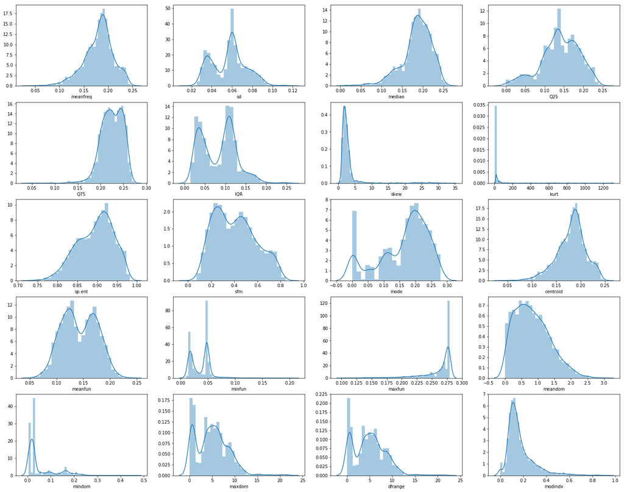

```python
# 绘制各feature的频数频数直方图
import math
col_len=4
row_len=math.ceil(len(features_names)/4)
f, axes = plt.subplots(row_len , col_len ,figsize=(25, 20))
i=0
for col in features_names:
    sns.distplot(df[col],ax=axes[i//col_len, i%col_len],axlabel='%s' % col);
    i+=1
plt.show()
```

[output not shown]

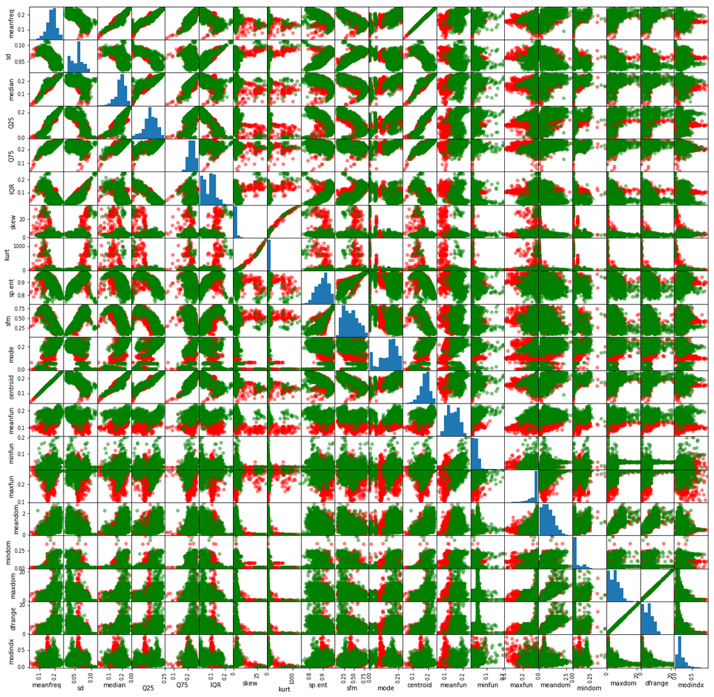

```python
colors={'male':'red','female':'green'}
pd.plotting.scatter_matrix(df,figsize=[20,20],marker='o',c=df['label'].apply(lambda x:colors[x]))
```

```python
# 偏斜数据使用Log转换
skewed=['skew','kurt','maxfun','modindx']
features_raw[skewed] = df[skewed].apply(lambda x: np.log(x + 1))
```

```python
# 对label 编码成数值
label = label_raw.replace(['male','female'],[0,1])
```

### 切分数据

将数据切分成训练集和测试集，80%的数据用于训练和20%的数据用于测试。训练集中进一步切分出80%的训练集和20%的验证集。

```python
from sklearn.model_selection import train_test_split
X_train, X_test, y_train, y_test = train_test_split(features_raw, label, test_size = 0.2, random_state = 0,
                                                    stratify = label)
X_train, X_val, y_train, y_val = train_test_split(X_train, y_train, test_size=0.2, random_state=0,
                                                    stratify = y_train)

print("size of X_train: {}".format(X_train.shape[0]))
print("size of X_test: {}".format(X_test.shape[0]))
print("size of X_val: {}".format(X_val.shape[0]))
```

```
size of X_train: 2027
size of X_test: 634
size of X_val: 507
```

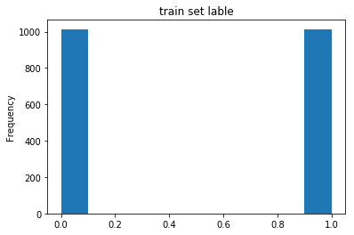

```python
y_train.plot(kind='hist',title='train set lable')
```

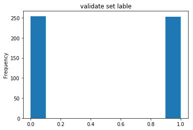

```python
y_val.plot(kind='hist',title='validate set lable')
```

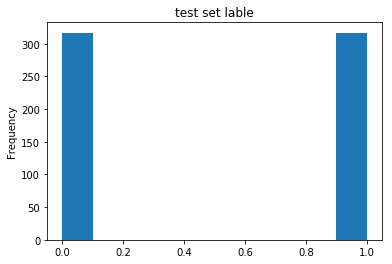

```python
y_test.plot(kind='hist',title='test set lable')
```

切分出的数据男女比例是均衡的

### 模型的训练框架

针对不同模型，提供同一种训练框架，返回不同的准确率。

```python
from sklearn.metrics import accuracy_score

def train_predict(model, X_train,y_train,X_val,y_val):
    results={}
    model=model.fit(X_train,y_train)
    predictions_val=model.predict(X_val)
    results['model']=model.__class__.__name__
    results['acc_val']=accuracy_score(y_val,predictions_val)
    return results
```

### 初始模型评估

对SVM、随机森林和XGBoost进行初步的评估

```python
from sklearn.ensemble import RandomForestClassifier
from xgboost import XGBClassifier
from sklearn.svm import SVC
random_state=10

clf_A=RandomForestClassifier(random_state=random_state)
clf_B=XGBClassifier(random_state=random_state)
clf_C=SVC(random_state=random_state) #默认SVC是rbf
print(train_predict(clf_A,X_train,y_train,X_val,y_val))
print(train_predict(clf_B,X_train,y_train,X_val,y_val))
print(train_predict(clf_C,X_train,y_train,X_val,y_val))
```

```
{'model': 'RandomForestClassifier', 'acc_val': 0.9625246548323472}
{'model': 'XGBClassifier', 'acc_val': 0.9704142011834319}
{'model': 'SVC', 'acc_val': 0.7396449704142012}
```

```python
# 随机森林在测试机上的准确率
clf_A = clf_A.fit(X_train,y_train)
predict = clf_A.predict(X_test)
print(accuracy_score(y_test,predict))
print("Accuracy on test data: {:.4f}".format(accuracy_score(y_test,predict)))
```

```
0.9763406940063092
Accuracy on test data: 0.9763
```

```python
# XGBoost在测试机上的准确率
clf_B = clf_B.fit(X_train,y_train)
predict = clf_B.predict(X_test)
print(accuracy_score(y_test,predict))
print("Accuracy on test data: {:.4f}".format(accuracy_score(y_test,predict)))
```

```
0.9763406940063092
Accuracy on test data: 0.9763
```

```python
clf_C = clf_C.fit(X_train,y_train)
predict = clf_C.predict(X_test)
print(accuracy_score(y_test,predict))
print("Accuracy on test data: {:.4f}".format(accuracy_score(y_test,predict)))
```

```
0.7681388012618297
Accuracy on test data: 0.7681
```

### 初始模型结果评价

无初始化值的RadomForestClassifier在验证集上的准确率可以达到96.25%，而XGBClassifier可以达到97.04%,两个模型都有很好的效果； 二在测试集上的结果都是97.63%。 SVC在验证集上的准确率可以达到73.96%，测试集上是76.81%。

### 调参

使用GridSearchCV调整模型的参数

```python
from sklearn.model_selection import GridSearchCV
warnings.filterwarnings('ignore')
#调优函数
def tuning(model,test_param,X_train,y_train,cv=5):
    grid_obj = GridSearchCV(estimator=model, param_grid=test_param, scoring='accuracy', n_jobs=4, iid=False, cv=cv)
    grid_obj = grid_obj.fit(X_train,y_train)

    best_clf = grid_obj.best_estimator_
    predictions = (model.fit(X_train, y_train)).predict(X_val)
    best_predictions = best_clf.predict(X_val)

    print("Unoptimized score: {}, Optimized score: {}".format(accuracy_score(y_val,predictions),
                                                  accuracy_score(y_val,best_predictions)))
    print("Best Params: {}, Best Score: {}".format(grid_obj.best_params_,grid_obj.best_score_))
    return grid_obj.best_params_;
```

## 随机森林调优

```python
# 随机森林调优
rf_clf = RandomForestClassifier(random_state=random_state)
parameters = {'n_estimators' : range(10,100,5),'max_depth':range(3,200,5)}
tuning(rf_clf,parameters,X_train,y_train)
```

```
Unoptimized score: 0.9625246548323472, Optimized score: 0.9664694280078896
Best Params: {'max_depth': 13, 'n_estimators': 95}, Best Score: 0.9817465977577505
```

```
{'max_depth': 13, 'n_estimators': 95}
```

```python
rf_clf = RandomForestClassifier(random_state=random_state,n_estimators=95,max_depth=13)
rf_clf.fit(X_train,y_train)
test_predict=rf_clf.predict(X_test)
print('Accuracy Score(test): {}'.format(accuracy_score(y_test,test_predict)))
```

```
Accuracy Score(test): 0.9810725552050473
```

随机森林在测试集上的准确率达到98.11%

## XGBoost调优

```python
import xgboost as xgb
```

```python
def xgb_model_cv(model, X, y, cv_folds=5, early_stopping_rounds=50, seed=0):
    xgb_param = model.get_xgb_params()
    xgtrain = xgb.DMatrix(X, label=y)
    cvresult = xgb.cv(xgb_param, xgtrain, num_boost_round=model.get_params()['n_estimators'], nfold=cv_folds,
                    metrics='auc', seed=seed, callbacks=[
            xgb.callback.print_evaluation(show_stdv=False),
            xgb.callback.early_stop(early_stopping_rounds)
       ])
    num_round_best = cvresult.shape[0] - 1
    print('Best round num: ', num_round_best)
    return num_round_best
```

```python
num_round = 1000
seed = 0
max_depth = 3
min_child_weight = 7
gamma = 0
subsample = 0.8
colsample_bytree = 0.8
scale_pos_weight = 1
reg_alpha = 1
reg_lambda = 1e-5
learning_rate = 0.1
model = XGBClassifier(random_state=random_state,learning_rate=learning_rate, n_estimators=num_round, max_depth=max_depth,
                      min_child_weight=min_child_weight, gamma=gamma, subsample=subsample, reg_alpha=reg_alpha,
                      reg_lambda=reg_lambda, colsample_bytree=colsample_bytree, objective='binary:logistic',
                      nthread=4, scale_pos_weight=scale_pos_weight, seed=seed)
num_round = xgb_model_cv(model, X_train, y_train)
```

```
Multiple eval metrics have been passed: 'test-auc' will be used for early stopping.

Will train until test-auc hasn't improved in 50 rounds.
Stopping. Best iteration:

Best round num:  160
```

xgboost 的n_estimators最优为160

```python
param_test1 = {
    'max_depth': range(3, 10, 2),
    'min_child_weight': range(1, 10, 2)
}
tuning(model, param_test1, X_train, y_train)
```

```
Unoptimized score: 0.9684418145956607, Optimized score: 0.9723865877712031
Best Params: {'max_depth': 3, 'min_child_weight': 1}, Best Score: 0.9822416532841023
```

```
{'max_depth': 3, 'min_child_weight': 1}
```

```python
param_test2 = {
    'gamma': [i / 10.0 for i in range(0, 5)]
}
tuning(model, param_test2, X_train, y_train)
```

```
Unoptimized score: 0.9684418145956607, Optimized score: 0.9684418145956607
Best Params: {'gamma': 0.1}, Best Score: 0.9817466037791519
```

```
{'gamma': 0.1}
```

```python
param_test3 = {
    'learning_rate': [i *0.01 for i in range(0, 11)]
}
tuning(model, param_test3, X_train, y_train)
```

```
Unoptimized score: 0.9684418145956607, Optimized score: 0.9704142011834319
Best Params: {'learning_rate': 0.04}, Best Score: 0.9827330417770842
```

```
{'learning_rate': 0.04}
```

```python
# tune reg_alpha
param_test4 = {
    'reg_alpha': [1e-5, 1e-2, 0.1, 1, 100, 1000]
}
tuning(model, param_test4,  X_train, y_train)
```

```
Unoptimized score: 0.9684418145956607, Optimized score: 0.9664694280078896
Best Params: {'reg_alpha': 1e-05}, Best Score: 0.9802626776087571
```

```
{'reg_alpha': 1e-05}
```

```python
# tune reg_lambda
param_test5 = {
    'reg_lambda': [1e-5, 1e-2, 0.1, 1, 100, 1000]
}
tuning(model, param_test5,  X_train, y_train)
```

```
Unoptimized score: 0.9684418145956607, Optimized score: 0.9684418145956607
Best Params: {'reg_lambda': 1e-05}, Best Score: 0.9802614552643003
```

```
{'reg_lambda': 1e-05}
```

```python
param_test7 = {
    'subsample': [i *0.1 for i in range(6, 10)],
    'colsample_bytree': [i *0.1 for i in range(6, 10)]
}
tuning(model, param_test7,  X_train, y_train)
```

```
Unoptimized score: 0.9684418145956607, Optimized score: 0.9704142011834319
Best Params: {'colsample_bytree': 0.7000000000000001, 'subsample': 0.9}, Best Score: 0.9822379922721337
```

```
{'colsample_bytree': 0.7000000000000001, 'subsample': 0.9}
```

```python
param_test6={
    'max_depth': [3], 'min_child_weight': [1],'learning_rate':[0.04],
    'gamma': [0.1],'reg_lambda': [1e-05],'reg_alpha': [1e-05],'n_estimators':[160],
    'colsample_bytree':[0.7],'subsample':[0.9]
}
tuning(model, param_test6,  X_train, y_train)
```

```
Unoptimized score: 0.9684418145956607, Optimized score: 0.9664694280078896
Best Params: {'colsample_bytree': 0.7, 'gamma': 0.1, 'learning_rate': 0.04, 'max_depth': 3, 'min_child_weight': 1, 'n_estimators': 160, 'reg_alpha': 1e-05, 'reg_lambda': 1e-05, 'subsample': 0.9}, Best Score: 0.9812539869203121
```

```
{'colsample_bytree': 0.7,
 'gamma': 0.1,
 'learning_rate': 0.04,
 'max_depth': 3,
 'min_child_weight': 1,
 'n_estimators': 160,
 'reg_alpha': 1e-05,
 'reg_lambda': 1e-05,
 'subsample': 0.9}
```

```python
num_round = 160
max_depth = 3
min_child_weight = 1
lerning_rate = 0.04
gamma = 0.1
reg_lambda = 1e-05
reg_alpha = 1e-05
n_estimators = 160
subsample = 0.9
colsample_bytree = 0.7
xgb_clf = XGBClassifier(random_state=random_state,learning_rate=learning_rate, n_estimators=num_round, max_depth=max_depth,
                      min_child_weight=min_child_weight, gamma=gamma, subsample=subsample, reg_alpha=reg_alpha,
                      reg_lambda=reg_lambda, colsample_bytree=colsample_bytree, objective='binary:logistic',
                      nthread=4, scale_pos_weight=scale_pos_weight, seed=seed)
xgb_clf.fit(X_train,y_train)
test_predict=xgb_clf.predict(X_test)
print('Accuracy Score(test): {}'.format(accuracy_score(y_test,test_predict)))
```

```
Accuracy Score(test): 0.9810725552050473
```

## SVM调优

```python
#SVC 调优
svm_clf = SVC(random_state=random_state)
param_test = [{'kernel': ['rbf'], 'gamma': [1e-3, 1e-4],'C': [0.1, 1, 10, 50, 100, 1000]},
            {'kernel': ['linear'], 'C': [0.1, 1, 10, 50, 100, 1000]}]
tuning(svm_clf,param_test,X_train,y_train)
```

```
Unoptimized score: 0.7396449704142012, Optimized score: 0.9644970414201184
Best Params: {'C': 1000, 'kernel': 'linear'}, Best Score: 0.9738502104178671
```

```
{'C': 1000, 'kernel': 'linear'}
```

```python
svm_clf = SVC(random_state=random_state,C=1000,kernel='linear')
svm_clf.fit(X_train,y_train)
test_predict = svm_clf.predict(X_test)
print('Accuracy Score(test): {}'.format(accuracy_score(y_test,test_predict)))
```

```
Accuracy Score(test): 0.9794952681388013
```

### 重要特征提取

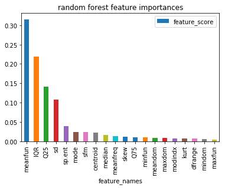

```python
# 随机森林特征重要性
rf_features_scores=pd.DataFrame({'feature_names':features_names,'feature_score':rf_clf.feature_importances_})
rf_features_scores=rf_features_scores.sort_values(by=['feature_score'],ascending=False)
rf_features_scores.plot(kind='bar',x='feature_names',y='feature_score',title='random forest feature importances')
```

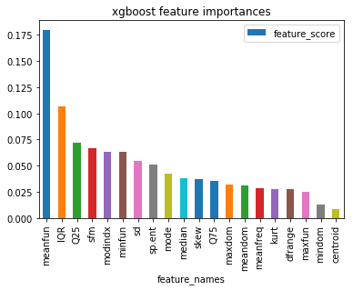

```python
# XGBoost特征重要性
xgb_features_scores=pd.DataFrame({'feature_names':features_names,'feature_score':xgb_clf.feature_importances_})
xgb_features_scores=xgb_features_scores.sort_values(by=['feature_score'],ascending=False)
xgb_features_scores.plot(kind='bar',x='feature_names',y='feature_score',title='xgboost feature importances')
```

### 测试集上计算准确率

以上三个模型在测试集上的准确率为：

- 随机森林：98.11%
- xgboost：98.11%
- SVM：97.95%

## 模型融合

https://mlwave.com/kaggle-ensembling-guide/  
http://scikit-learn.org/stable/modules/generated/sklearn.ensemble.VotingClassifier.html

```python
import numpy as np
from sklearn.svm import SVC
from xgboost import XGBClassifier
from sklearn.ensemble import RandomForestClassifier, VotingClassifier
clf1 = RandomForestClassifier(random_state=random_state,n_estimators=95,max_depth=13)
clf2 = XGBClassifier(random_state=random_state,learning_rate=learning_rate, n_estimators=num_round, max_depth=max_depth,
                      min_child_weight=min_child_weight, gamma=gamma, subsample=subsample, reg_alpha=reg_alpha,
                      reg_lambda=reg_lambda, colsample_bytree=colsample_bytree, objective='binary:logistic',
                      nthread=4, scale_pos_weight=scale_pos_weight, seed=seed)
clf3 = SVC(random_state=random_state,C=1000,kernel='linear')
```

```python
eclf1 = VotingClassifier(estimators=[
             ('rf', clf1), ('xgb', clf2), ('svc', clf3)], voting='hard')
eclf1 = eclf1.fit(X_train, y_train)

predict_test = eclf1.predict(X_test)
print('Accuracy (test):{}'.format(accuracy_score(y_test,predict_test)))
```

```
Accuracy (test):0.9810725552050473
```